# midterm

Yinuo Liu

6/10/2020

*One of the treatments for bladder cancer is the surgical removal of the bladder tumor. It can be performed manually by a surgeon, or with a robotic surgical tool, supervised by a surgeon. Robotic removal is much faster, leading to fewer surgical complications.*

*Three studies were independently conducted by three groups of medical researchers to evaluate the effect of robotic surgical tool on operation time. Each group estimated the average time saved by use of the robotic surgical tool, after appropriate adjustments are made for other factors.*

*Combine these studies, and find an overall estimate for average time saved by use of robotic surgical tool. Also, report a standard error of your estimate.*

*Find a 95% interval for your estimate for average time saved.*

*Plot the posterior densities of average time saved (overall), and the heterogeneity parameter (τ). In each case, use appropriate limits for the x-axis in the figure, so that the shape of the density is clearly understood from the plot.*

*Note: Remember that selecting a prior can be a subjective exercise. Use a prior that you think is appropriate, taking into account the fact that robotic surgeries are much faster.*

Meta Analysis to combine the 3 studies:

```r
n_samples <- c(49,56,32)
beta_mean <- c(0.35,1.2,0.91)
beta_sd <- c(0.18,0.51,0.47)

# run bayesian meta-analysis
ma <- bayesmeta(beta_mean,
                beta_sd,
                mu.prior.mean=0.5,
                mu.prior.sd=1,
                tau.prior=function(x){dhalfnormal(x,scale=0.5)})
```

To specify the prior distribution for the effect of μ, we set it follows a normal distribution with N(0.5,1), we take into account the fact that robotic surgeries are much faster, we the prior mean of μ is 0.5. And th prior distribution of τ is half-normal distribution with scale=0.5.

```r
#show some summary statistics:
print(ma)
```

```
##  'bayesmeta' object.
##
## 3 estimates:
## 01, 02, 03
##
## tau prior (proper):
## function(x){dhalfnormal(x,scale=0.5)}
## <bytecode: 0x7fa8e75dad38>
##
## mu prior (proper):
## normal(mean=0.5, sd=1)
##
## ML and MAP estimates:
##                       tau        mu
## ML joint     0.000000e+00 0.4979021
## ML marginal  3.067389e-01 0.5665074
## MAP joint    1.423384e-05 0.4979514
## MAP marginal 2.168843e-01 0.5626971
##
## marginal posterior summary:
##                 tau         mu
## mode      0.2168843 0.56269714
## median    0.3057517 0.60261327
## mean      0.3476635 0.62508806
## sd        0.2455882 0.30260138
## 95% lower 0.0000000 0.05554825
## 95% upper 0.8128776 1.26963535
##
## (quoted intervals are shortest credible intervals.)
```

```r
a<-print(ma)
```

```
##  'bayesmeta' object.
##
## 3 estimates:
## 01, 02, 03
##
## tau prior (proper):
## function(x){dhalfnormal(x,scale=0.5)}
## <bytecode: 0x7fa8e75dad38>
##
## mu prior (proper):
## normal(mean=0.5, sd=1)
##
## ML and MAP estimates:
##                       tau        mu
## ML joint     0.000000e+00 0.4979021
## ML marginal  3.067389e-01 0.5665074
## MAP joint    1.423384e-05 0.4979514
## MAP marginal 2.168843e-01 0.5626971
##
## marginal posterior summary:
##                 tau         mu
## mode      0.2168843 0.56269714
## median    0.3057517 0.60261327
## mean      0.3476635 0.62508806
## sd        0.2455882 0.30260138
## 95% lower 0.0000000 0.05554825
## 95% upper 0.8128776 1.26963535
##
## (quoted intervals are shortest credible intervals.)
```

```r
a$summary%>%round(2)
```

```
##            tau   mu theta
## mode      0.22 0.56  0.53
## median    0.31 0.60  0.59
## mean      0.35 0.63  0.63
## sd        0.25 0.30  0.52
## 95% lower 0.00 0.06 -0.41
## 95% upper 0.81 1.27  1.78
```

```r
# 95% Credible Interval
ma$post.interval(mu = 0.95)%>%round(2)
```

```
## [1] 0.06 1.27
## attr(,"interval.type")
## [1] "shortest"
```

The 95% credible interval for the estimate of average time saved μ is (0.06, 1.27).

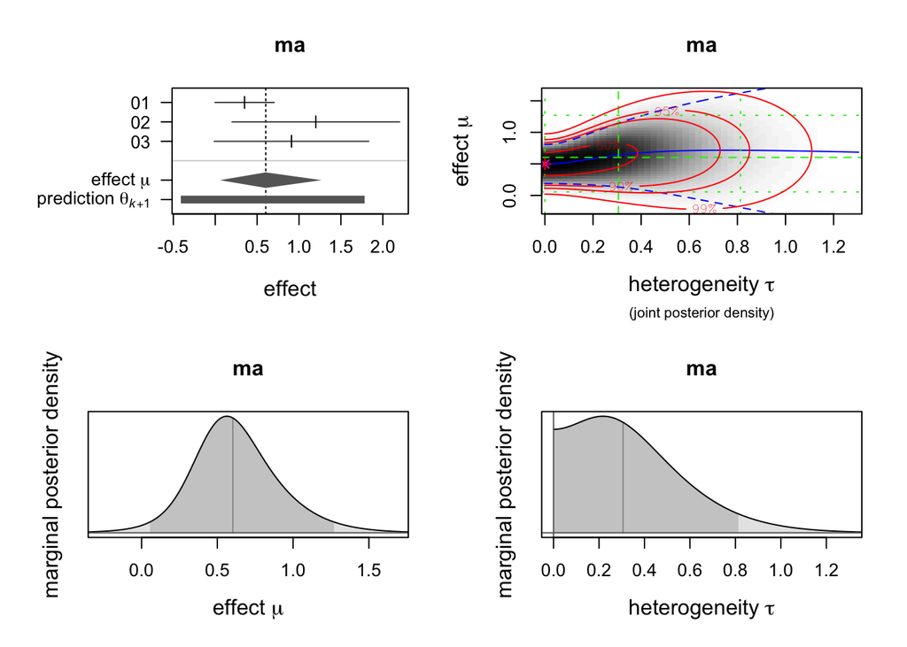

```r
#show some plots
par(mfrow=c(2,2))
plot(ma)
```

- Plot 2: Shows the joint posterior density of heterogeneity τ and effect µ, with darker shading corresponding to higher probability density.
  - The red lines indicate (approximate) 2D credible regions.
  - The green lines show marginal posterior medians and 95% credible intervals.
  - The blue lines show the conditional posterior mean effect as a function of the heterogeneity τ along with a 95% interval based on its conditional standard error.
- Plot 3 and Plot 4: Shows the marginal posterior densities of effect µ and heterogeneity τ. 95% credible intervals are indicated with a darker shading, and the posterior median is shown by a vertical line.